# Endotherm Model Tutorial II: component functions

Michael Kearney

2026-04-01

## Overview

This document provides an overview of an R implementation of the NicheMapR endotherm model, via the sub-functions of ‘endoR’ and ‘endoR_devel’. This implementation modularises the original version such that many of the internal subroutines and functions can be called separately. The idea is that the user has more flexibility in setting the model up for the behavioural and physiological responses of a particular animal. All the underlying theory, equations and subroutines are described in Endotherm Theory Tutorial. Also the Endotherm Model Tutorial shows how to use ‘endoR’ (and ‘endoR_devel’) as a whole.

```r
library(NicheMapR)
library(knitr)
library(plotrix)
```

## Running the separate subroutines

### IRPROP

This subroutine computes the three parameters needed for computing conduction and infrared radiation through the fur.

```r
# environmental input
TA <- 20  # air temperature, for calculation of conductivity of air (°C)

# shape input
PVEN <- 0.3  # maximum fraction of surface area that is ventral (fractional, 0-1)

# fur properties
DHAIRD <- 3e-05  # hair diameter, dorsal (m)
DHAIRV <- 3e-05  # hair diameter, ventral (m)
LHAIRD <- 0.0239  # hair length, dorsal (m)
LHAIRV <- 0.0239  # hair length, ventral (m)
ZFURD <- 0.009  # fur depth, dorsal (m)
ZFURV <- 0.009  # fur depth, ventral (m)
ZFURCOMP <- ZFURV  # depth of compressed fur (for conduction) (m)
RHOD <- 39680000  # hair density, dorsal (1/m2)
RHOV <- 27810000  # hair density, ventral (1/m2)
REFLD <- 0.301  # fur reflectivity dorsal (fractional, 0-1)
REFLV <- 0.301  # fur reflectivity ventral (fractional, 0-1)
KHAIR <- 0.209  # hair thermal conductivity (W/m°C)

# call the subroutine
IRPROP.out <- IRPROP(TA, DHAIRD, DHAIRV, LHAIRD, LHAIRV, ZFURD,
    ZFURV, RHOD, RHOV, REFLD, REFLV, ZFURCOMP, PVEN, KHAIR)

# output
KEFARA <- IRPROP.out[1:3]  # effective thermal conductivity of fur array, mean, dorsal, ventral (W/mK)
BETARA <- IRPROP.out[4:6]  # term involved in computing optical thickness (1/m)
B1ARA <- IRPROP.out[7:9]  # optical thickness array, mean, dorsal, ventral (-)
DHAR <- IRPROP.out[10:12]  # fur diameter array, mean, dorsal, ventral (m)
LHAR <- IRPROP.out[13:15]  # fur length array, mean, dorsal, ventral (m)
RHOAR <- IRPROP.out[16:18]  # fur density array, mean, dorsal, ventral (fibers/m2)
ZZFUR <- IRPROP.out[19:21]  # fur depth array, mean, dorsal, ventral (m)
REFLFR <- IRPROP.out[22:24]  # fur reflectivity array, mean, dorsal, ventral (fractional, 0-1)
FURTST <- IRPROP.out[25]  # test of presence of fur (length x diameter x density x depth) (-)
KFURCMPRS <- IRPROP.out[26]  # effective thermal conductivity of compressed ventral fur (W/mK)

IRPROP.lab <- c("KEFARA mean", "KEFARA dorsal", "KEFARA ventral",
    "BETARA mean", "BETARA dorsal", "BETARA ventral", "B1ARA mean",
    "B1ARA dorsal", "B1ARA ventral", "DHAR mean", "DHAR dorsal",
    "DHAR ventral", "LHAR mean", "LHAR dorsal", "LHAR ventral",
    "RHOAR mean", "RHOAR dorsal", "RHOAR ventral", "ZZFUR mean",
    "ZZFUR dorsal", "ZZFUR ventral", "REFLFR mean", "REFLFR dorsal",
    "REFLFR ventral", "FURTST", "KFURCMPRS")
kable(cbind(IRPROP.lab, IRPROP.out[1:26]))
```

[output not shown]

Example analysis of fur diameter on effective thermal conductivity of fur. Note this does not include the radiative component of fur conductivity, which is calculated in SIMULSOL. Empirical measurements of fur thermal conductivity will include both the radiative and conductive aspects.

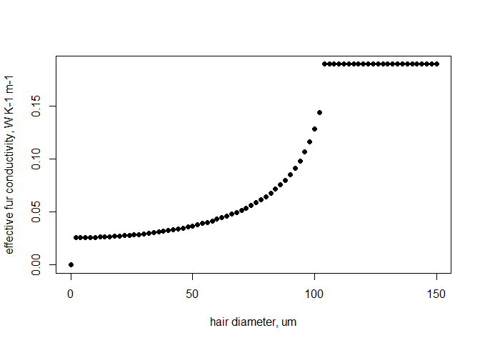

```r
DHAIRs <- seq(0, 150, 2)  # hair diameters (micrometers)
KEFARAs <- NULL
for (i in 1:length(DHAIRs)) {
    KEFARAs[i] <- IRPROP(TA, DHAIRs[i] * 1e-06, DHAIRs[i] * 1e-06,
        LHAIRD, LHAIRV, ZFURD, ZFURV, RHOD, RHOV, REFLD, REFLV,
        ZFURCOMP, PVEN, KHAIR)[1]
}
plot(KEFARAs ~ DHAIRs, type = "p", pch = 16, ylab = "effective fur conductivity, W K-1 m-1",
    xlab = "hair diameter, um")
```

Example analysis of fur density on effective thermal conductivity of fur.

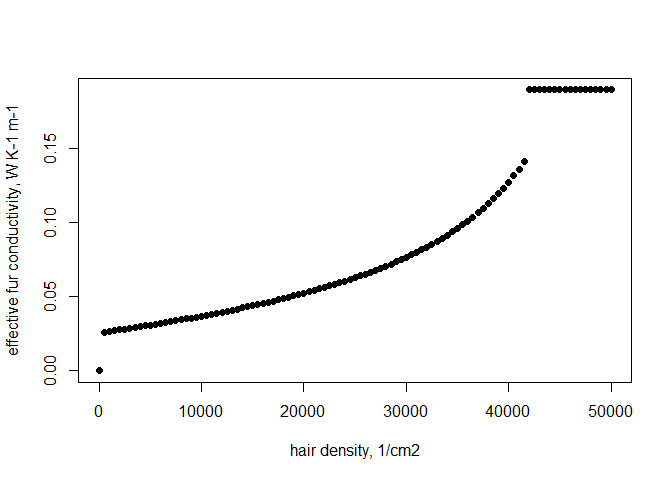

```r
RHOs <- seq(0, 50000, 500)  # hair densities (1/cm2)
KEFARAs <- NULL
for (i in 1:length(RHOs)) {
    KEFARAs[i] <- IRPROP(TA, DHAIRD, DHAIRV, LHAIRD, LHAIRV,
        ZFURD, ZFURV, RHOs[i] * 10000, RHOs[i] * 10000, REFLD,
        REFLV, ZFURCOMP, PVEN, KHAIR)[1]
}
plot(KEFARAs ~ RHOs, type = "p", pch = 16, ylab = "effective fur conductivity, W K-1 m-1",
    xlab = "hair density, 1/cm2")
```

Example analysis of fur depth on effective thermal conductivity of fur.

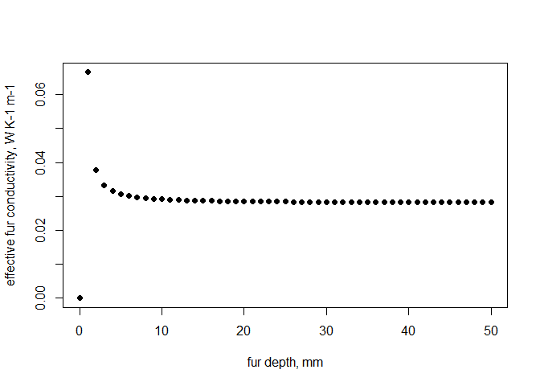

```r
ZFURs <- seq(0, 50, 1)  # hair depths (mm)
KEFARAs <- NULL
for (i in 1:length(ZFURs)) {
    KEFARAs[i] <- IRPROP(TA, DHAIRD, DHAIRV, LHAIRD, LHAIRV,
        ZFURs[i] * 0.001, ZFURs[i] * 0.001, RHOD, RHOV, REFLD,
        REFLV, ZFURCOMP, PVEN, KHAIR)[1]
}
plot(KEFARAs ~ ZFURs, type = "p", pch = 16, ylab = "effective fur conductivity, W K-1 m-1",
    xlab = "fur depth, mm")
```

### GEOM_ENDO

This subroutine computes aspects of the animal’s geometry. Note that GEOM_ENDO requires outputs from IRPROP on fur properties. Note also that this routine is called ‘allom’ in past versions of ‘Niche Mapper’.

```r
# input
AMASS <- 10  # animal mass (kg)
ANDENS <- 1000  # flesh density (kg/m3)
FATDEN <- 901  # fat density (kg/m3)
SUBQFAT <- 1  # is subcutaneous fat present? (0 is no, 1 is yes)
FATPCT <- 20  # body fat (%)
SHAPE <- 4  # shape, 1 is cylinder, 2 is sphere, 3 is plate, 4 is ellipsoid
SHAPE_B <- 2.7  # current ratio between long and short axis (-)
SHAPE_C <- SHAPE_B  # current ratio of length:height (for plate)
DHARA <- DHAR[1]  # fur diameter, mean (m) (from IRPROP)
RHOARA <- RHOAR[1]  # hair density, mean (1/m2) (from IRPROP)
ZFUR <- ZZFUR[1]  # fur depth, mean (m) (from IRPROP)
PCOND <- 0  # fraction of body in contact with substrate (fractional, 0-1)
SAMODE <- 0  # if 1, uses bird skin surface area scaling from Walsberg
# and King 1978. JEB Biology 76:185–189, if 2, uses mammal
# surface area scaling from Stahl (1967) J. of App.
# Physiology, 453–460.
ORIENT <- 0  # if 1, largest surface area normal to sun's ray's, if 2, largest surface parallel to sun's rays, if 0, average of normal/parallel posture
Z <- 20  # zenith angle of the sun
ZEN <- pi/180 * Z  # convert degrees to radians

# call the subroutine
GEOM.out <- GEOM_ENDO(AMASS, ANDENS, FATDEN, FATPCT, SHAPE, ZFUR,
    SUBQFAT, SHAPE_B, SHAPE_C, DHARA, RHOARA, PCOND, SAMODE,
    ORIENT, ZEN)

# output
VOL <- GEOM.out[1]  # volume (m3)
D <- GEOM.out[2]  # characteristic dimension for convection (m)
MASFAT <- GEOM.out[3]  # mass body fat (kg)
VOLFAT <- GEOM.out[4]  # volume body fat (m3)
ALENTH <- GEOM.out[5]  # length (m)
AWIDTH <- GEOM.out[6]  # width (m)
AHEIT <- GEOM.out[7]  # height (m)
ATOT <- GEOM.out[8]  # total area at fur/feathers-air interface (m2)
ASIL <- GEOM.out[9]  # silhouette area to use in solar calcs (m2) may be normal, parallel
# or average set via ORIENT
ASILN <- GEOM.out[10]  # silhouette area normal to sun (m2)
ASILP <- GEOM.out[11]  # silhouette area parallel to sun (m2)
GMASS <- GEOM.out[12]  # mass (g)
AREASKIN <- GEOM.out[13]  # area of skin (m2)
FLSHVL <- GEOM.out[14]  # flesh volume (m3)
FATTHK <- GEOM.out[15]  # fat layer thickness (m)
ASEMAJ <- GEOM.out[16]  # semimajor axis length (m)
BSEMIN <- GEOM.out[17]  # b semiminor axis length (m)
CSEMIN <- GEOM.out[18]  # c semiminor axis length (m)
# (currently only prolate spheroid)
CONVSK <- GEOM.out[19]  # area of skin for evaporation (total skin area - hair area) (m2)
CONVAR <- GEOM.out[20]  # area for convection (total area minus ventral area in contact
# with the substrate, as determined by PCOND), m2
R1 <- GEOM.out[21]  # shape-specific core-skin radius in shortest dimension (m)
R2 <- GEOM.out[22]  # shape-specific core-fur radius in shortest dimension (m)
ACOND <- ATOT * PCOND

GEOM.lab <- c("VOL", "D", "MASFAT", "VOLFAT", "ALENTH", "AWIDTH",
    "AHEIT", "ATOT", "ASIL", "ASILN", "ASILP", "GMASS", "AREASKIN",
    "FLSHVL", "FATTHK", "ASEMAJ", "BSEMIN", "CSEMIN", "CONVSK",
    "CONVAR", "R1", "R2")
kable(cbind(GEOM.lab, t(GEOM.out)))
```

| GEOM.lab |  |
| --- | --- |
| VOL | 0.01 |
| D | 0.224443459147026 |
| MASFAT | 2 |
| VOLFAT | 0.00221975582685905 |
| ALENTH | 0.514307935729251 |
| AWIDTH | 0.214166582142777 |
| AHEIT | 0.214166582142777 |
| ATOT | 0.289241330612817 |
| ASIL | 0.0612669070466275 |
| ASILN | 0.0865097013515642 |
| ASILP | 0.0360241127416909 |
| GMASS | 10000 |
| AREASKIN | 0.254313832458145 |
| FLSHVL | 0.00778024417314096 |
| FATTHK | 0.00980642236948426 |
| ASEMAJ | 0.248153967864625 |
| BSEMIN | 0.0980832910713883 |
| CSEMIN | 0.0980832910713883 |
| CONVSK | 0.247820941770541 |
| CONVAR | 0.289241330612817 |
| R1 | 0.0980832910713883 |
| R2 | 0.107083291071388 |

Plot of current animal configuration.

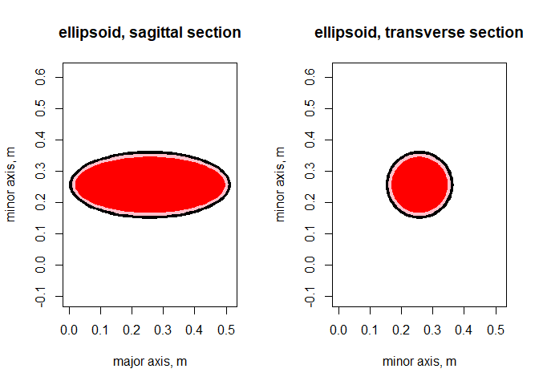

```r
if (SHAPE == 4) {
    # ellipsoid
    par(mfrow = c(1, 2))
    plot(c(0, ASEMAJ * 2 + ZFUR * 2), c(0, ASEMAJ * 2 + ZFUR *
        2), type = "n", main = "ellipsoid, sagittal section",
        ylab = "minor axis, m", xlab = "major axis, m", asp = 1)
    draw.ellipse(ASEMAJ + ZFUR, ASEMAJ + ZFUR, col = "black",
        border = "black", a = ASEMAJ + ZFUR, b = BSEMIN + ZFUR)
    draw.ellipse(ASEMAJ + ZFUR, ASEMAJ + ZFUR, col = "pink",
        border = "pink", a = ASEMAJ, b = BSEMIN)
    draw.ellipse(ASEMAJ + ZFUR, ASEMAJ + ZFUR, col = "red", border = "red",
        a = ASEMAJ - FATTHK, b = BSEMIN - FATTHK)

    plot(c(0, ASEMAJ * 2 + ZFUR * 2), c(0, ASEMAJ * 2 + ZFUR *
        2), type = "n", main = "ellipsoid, transverse section",
        ylab = "minor axis, m", xlab = "minor axis, m", asp = 1)
    draw.ellipse(ASEMAJ + ZFUR, ASEMAJ + ZFUR, col = "black",
        border = "black", a = BSEMIN + ZFUR, b = CSEMIN + ZFUR)
    draw.ellipse(ASEMAJ + ZFUR, ASEMAJ + ZFUR, col = "pink",
        border = "pink", a = BSEMIN, b = CSEMIN)
    draw.ellipse(ASEMAJ + ZFUR, ASEMAJ + ZFUR, col = "red", border = "red",
        a = BSEMIN - FATTHK, b = CSEMIN - FATTHK)
    par(mfrow = c(1, 1))
}
```

### SOLAR_ENDO

Compute the solar radiation absorbed by different parts of the organism and its environment.

```r
# environmental variables
QSOLR <- 1000  # solar radiation, horizontal plane (W/m2)
SHADE <- 0  # shade (%, 0-100)
Z <- 20  # zenith angle of sun (degrees from overhead)
ABSSB <- 0.8  # solar absorptivity of substrate (fractional, 0-1)

# traits
AREA <- ATOT  # surface area for solar exchange, m2 (from GEOM)
ABSAND <- 0.8  # solar absorptivity of dorsal fur (fractional, 0-1)
ABSANV <- 0.8  # solar absorptivity of ventral fur (fractional, 0-1)
ASIL <- ASIL  # silhouette area to sun, m2 (from GEOM)
PDIF <- 0.15  # proportion of solar radiation that is diffuse (fractional, 0-1)
FASKY <- 0.4  # configuration factor to sky (-)
FAVEG <- 0  # configuration factor to vegetation (-)
AREACOND <- ACOND  # conduction area, m2

# solar radiation normal to sun's rays
ZEN <- pi/180 * Z  # convert degrees to radians
if (Z < 90) {
    # compute solar radiation on a surface normal to the
    # direct rays of the sun
    CZ <- cos(ZEN)
    QNORM <- QSOLR/CZ
} else {
    # diffuse skylight only
    QNORM <- QSOLR
}

SOLAR.out <- SOLAR_ENDO(AREA, AREACOND, ABSAND, ABSANV, ABSSB,
    ASIL, PDIF, QNORM, SHADE, QSOLR, FASKY, FAVEG)

QSOLAR <- SOLAR.out[1]  # total (global) solar radiation (W)
QSDIR <- SOLAR.out[2]  # direct solar radiation (W)
QSSKY <- SOLAR.out[3]  # diffuse solar radiation from sky (W)
QSRSB <- SOLAR.out[4]  # diffuse solar radiation reflected from substrate (W)
QSDIFF <- SOLAR.out[5]  # total diffuse solar radiation (W)
QDORSL <- SOLAR.out[6]  # dorsal direct solar radiation (W)
QVENTR <- SOLAR.out[7]  # ventral diffuse solar radiation (W)

SOLAR.lab <- c("QSOLAR", "QSDIR", "QSSKY", "QSRSB", "QSDIFF",
    "QDORSL", "QVENTR")
kable(cbind(SOLAR.lab, t(SOLAR.out)))
```

| SOLAR.lab |  |
| --- | --- |
| QSOLAR | 85.9859904620565 |
| QSDIR | 44.3352388538108 |
| QSSKY | 13.8835838694152 |
| QSRSB | 27.7671677388305 |
| QSDIFF | 41.6507516082457 |
| QDORSL | 58.218822723226 |
| QVENTR | 27.7671677388305 |

### CONV_ENDO

Compute convective heat exchange.

```r
# input
TS <- 33  # skin temperature (°C)
TENV <- 20  # air temperature (°C)
TFA <- 10  # fur/air interface temperature (°C)
SHAPE <- 4  # shape, 1 is cylinder, 2 is sphere, 3 is plate, 4 is ellipsoid
SURFAR <- CONVAR  # surface area for convection, m2 (from GEOM)
FLTYPE <- 0  # FLUID TYPE: 0 = AIR; 1 = FRESH WATER; 2 = SALT WATER
CONV_ENHANCE <- 1.4  # convective enhancement factor (-)
FURTST <- FURTST  # test of fur presence (-) from IRPROP
VEL <- 1  # wind speed (m/s)
ELEV <- 0  # elevation (m)
BP <- -1  # barometric pressure (Pa), negative means altitude is used
GRAV <- 9.80665  # acceleration due to gravity, m/s^2
O2GAS <- 20.95  # oxygen concentration of air (%)
N2GAS <- 79.02  # nitrogen concentration of air (%)
CO2GAS <- 0.0412  # carbon dioxide concentration of air (%)

# run subroutine
CONV.out <- CONV_ENDO(TS, TENV, SHAPE, SURFAR, FLTYPE, FURTST,
    D, TFA, VEL, ZFUR, BP, ELEV, GRAV, O2GAS, N2GAS, CO2GAS,
    CONV_ENHANCE)

QCONV <- CONV.out[1]  # convective heat loss (W)
HC <- CONV.out[2]  # combined convection coefficient (W/m2 C)
HCFREE <- CONV.out[3]  # free convection coefficient (W/m2 C)
HCFOR <- CONV.out[4]  # forced convection coefficient (W/m2 C)
HD <- CONV.out[5]  # mass transfer coefficient (kg/m2 s)
HDFREE <- CONV.out[6]  # free mass transfer coefficient (kg/m2 s)
HDFORC <- CONV.out[7]  # forced mass transfer coefficient (kg/m2 s)
ANU <- CONV.out[8]  # Nusselt number (-)
RE <- CONV.out[9]  # Reynold's number (-)
GR <- CONV.out[10]  # Grasshof number (-)
PR <- CONV.out[11]  # Prandtl number (-)
RA <- CONV.out[12]  # Rayleigh number (-)
SC <- CONV.out[13]  # Schmidt number (-)
BP <- CONV.out[14]  # barometric pressure (Pa)

CONV.lab <- c("QCONV", "HC", "HCFREE", "HCFOR", "HD", "HDFREE",
    "HDFORC", "ANU", "RE", "GR", "PR", "RA", "SC", "BP")
kable(cbind(CONV.lab, t(CONV.out)))
```

| CONV.lab |  |
| --- | --- |
| QCONV | -338.289087873957 |
| HC | 116.957381974845 |
| HCFREE | 4.70035239679984 |
| HCFOR | 116.954827212904 |
| HD | 0.11296109337565 |
| HDFREE | 0.00453974718848924 |
| HDFORC | 0.112958625906754 |
| ANU | 104.324998518356 |
| RE | 13300.4730203937 |
| GR | 28374932.0469349 |
| PR | 0.712515322862147 |
| RA | 20217573.8686133 |
| SC | 0.665735176697524 |
| BP | 101325 |

### SEVAP_ENDO

Compute evaporative heat exchange.

```r
BP <- BP  # barometric pressure (Pa) (from CONV)
TA <- 20  # air temperature (°C)
RELHUM <- 20  # relative humidity (%)
TC <- 37  # core temperature (°C)
TSKIN <- 33  # skin temperature (°C)
PCTWET <- 11  # part of the skin surface that is wet (%)
FLYHR <- 0  # is flight occurring this hour? (imposes forced evaporative loss)
BAREVAP <- 0  # is evaporation partly from bare skin? (0 = no, 1 = yes, % defined with PCTBAREVAP)
PCTBAREVAP <- 0  # surface area for evaporation that is skin, e.g. licking paws (%)
PCTEYES <- 0.03  # surface area made up by the eye (%) - make zero if sleeping
ZFUR <- ZFUR  # fur depth (m)
FURWET <- 0  # part of the fur surface that is wet (%)

SEVAP.out <- SEVAP_ENDO(BP, TA, RELHUM, VEL, TC, TSKIN, ELEV,
    PCTWET, FLYHR, CONVSK, HD, HDFREE, PCTBAREVAP, PCTEYES, ZFUR,
    FURWET, TFA, CONVAR)

QSEVAP <- SEVAP.out[1]  # skin evaporative heat loss (W)
WEYES <- SEVAP.out[2]  # ocular evaporation (kg/s)
WCUTHF <- SEVAP.out[3]  # forced cutaneous evaporation (kg/s)
WCUTF <- SEVAP.out[4]  # free cutaneous evaporation (kg/s)
WCUT <- SEVAP.out[5]  # total cutaneous evaporation (kg/s)
WTFUR <- SEVAP.out[6]  # total fur evaporation (kg/s)
QFSEVAP <- SEVAP.out[7]  # fur evaporative heat loss (W))

SEVAP.lab <- c("QSEVAP", "WEYES", "WCUTHF", "WCUTF", "WCUT",
    "WTFUR", "QFSEVAP")
kable(cbind(SEVAP.lab, t(SEVAP.out)))
```

| SEVAP.lab |  |
| --- | --- |
| QSEVAP | 10.4457438517194 |
| WEYES | 2.70531599818835e-07 |
| WCUTHF | 0 |
| WCUTF | 3.98650398432221e-06 |
| WCUT | 3.98650398432221e-06 |
| WTFUR | 0 |
| QFSEVAP | 0 |

### SIMULSOL

Setup and the SIMULSOL algorithm to SIMULtaneously SOLve for skin temperature $T_s$ and the temperature of the fur/feather interface $T_fa$ given an environment, shape/posture and skin wetness. SIMULSOL is the core algorithm for computing the heat balance.

```r
# environment
FLTYPE <- 0  # fluid type: 0 = air; 1 = fresh water; 2 = salt water
TAREF <- TA  # reference air temperature (e.g. at 1.2 or 2m) (°C)
TLOWER <- TA  # ground temperature (°C)
TSKY <- TA  # sky temperature (°C)
TCONDSB <- TA  # surface temperature for conduction (°C)
TBUSH <- TA  # bush temperature (°C)
TVEG <- TAREF  # assume vegetation casting shade is at reference (e.g. 1.2m or 2m) air temperature (°C)
RH <- 20  # relative humidity (%)
VEL <- 1  # wind speed (m/s)
BP <- BP  # barometric pressure (Pa), negative means altitude is used (from CONV)
ELEV <- 0  # elevation (m)
KSUB <- 2.79  # substrate thermal conductivity (W/m°C)

# physiology and morphology
PCTWET <- 0  # part of the skin surface that is wet (%)
AK1 <- 0.9  # initial thermal conductivity of flesh (0.412 - 2.8 W/mK)
AK2 <- 0.23  # conductivity of fat (W/mK)
XR <- 1  # fractional depth of fur at which longwave radiation is exchanged (0-1)
EMISAN <- 0.99  # animal emissivity (-)
BAREVAP <- 0  # is evaporation partly from bare skin? (0 = no, 1 = yes, % defined with PCTBAREVAP)
PCTBAREVAP <- 0  # surface area for evaporation that is skin, e.g. licking paws (%)
PCTEYES <- 0.03  # surface area made up by the eye (%) - make zero if sleeping
# behaviour
FLYHR <- 0  # is flight occurring this hour? (imposes forced evaporative loss)

# configuration factors
FAGRD <- 0.5  # configuration factor to ground (-)
FASKY <- 0.5  # configuration factor to sky (-)
FAVEG <- 0  # this is for overhead veg (at TAREF) (-)
FABUSH <- 0  # this is for veg below/around animal (at TALOC) (-)

# reference configuration factors
FABUSHREF <- FABUSH  # nearby bush (-)
FASKYREF <- FASKY  # sky (-)
FAGRDREF <- FAGRD  # ground (-)
FAVEGREF <- FAVEG  # vegetation (-)

FURTHRMK <- 0  # user-specified fur thermal conductivity (W/m C), not used if 0
SHAPE <- 4  # shape, 1 is cylinder, 2 is sphere, 3 is plate, 4 is ellipsoid

# Initial values
TS <- TC  # current guess of skin temperature (deg C)
TFA <- TA  # current guess of fur/air interface temperature (deg C)

DIFTOL <- 0.001  # tolerance for SIMULSOL

# vector to hold the SIMULSOL results for dorsal and
# ventral side
SIMULSOL.out <- matrix(data = 0, nrow = 2, ncol = 16)

# repeat for each side, dorsal and ventral, of the animal
for (S in 1:2) {

    # Calculating solar intensity entering fur. This will
    # depend on whether we are calculating the fur
    # temperature for the dorsal side or the ventral side.
    # The dorsal side will have solar inputs from the
    # direct beam hitting the silhouette area as well as
    # diffuse solar scattered from the sky. The ventral
    # side will have diffuse solar scattered off the
    # substrate.

    # Setting config factors and solar depending on whether
    # the dorsal side (S=1) or ventral side (S=2) is being
    # estimated.

    if (QSOLAR > 0) {
        if (S == 1) {
            # proportion of upward view that is sky
            FASKY <- FASKYREF/(FASKYREF + FAVEGREF)
            # proportion of upward view that is vegetation
            # (shade)
            FAVEG <- FAVEGREF/(FASKYREF + FAVEGREF)
            FAGRD <- 0
            FABUSH <- 0
            QSLR <- 2 * QSDIR + ((QSSKY/FASKYREF) * FASKY)  # direct x 2
            # because assuming sun in both directions, and
            # un-adjusting QSSKY for config factor imposed
            # in SOLAR_ENDO and back to new larger one in
            # both directions doing ventral side
        } else {
            FASKY <- 0
            FAVEG <- 0
            FAGRD <- FAGRDREF/(FAGRDREF + FABUSHREF)
            FABUSH <- FABUSHREF/(FAGRDREF + FABUSHREF)
            QSLR <- (QVENTR/(1 - FASKYREF - FAVEGREF)) * (1 -
                (2 * PCOND))  # un-adjust by
            # config factor imposed in SOLAR_ENDO to have
            # it coming in both directions, but also
            # cutting down according to fractional area
            # conducting to ground (in both directions)
        }
    } else {
        QSLR <- 0
        if (S == 1) {
            FASKY <- FASKYREF/(FASKYREF + FAVEGREF)
            FAVEG <- FAVEGREF/(FASKYREF + FAVEGREF)
            FAGRD <- 0
            FABUSH <- 0
        } else {
            FASKY <- 0
            FAVEG <- 0
            FAGRD <- FAGRDREF/(FAGRDREF + FABUSHREF)
            FABUSH <- FABUSHREF/(FAGRDREF + FABUSHREF)
        }
    }

    # set fur depth and conductivity index for KEFARA, the
    # conductivity, is the average (1), front/dorsal (2),
    # back/ventral(3) of the body part
    if (QSOLR > 0 | ZZFUR[2] != ZZFUR[3]) {
        if (S == 1) {
            ZL <- ZZFUR[2]
            KEFF <- KEFARA[2]
        } else {
            ZL <- ZZFUR[3]
            KEFF <- KEFARA[3]
        }
    } else {
        ZL <- ZZFUR[1]
        KEFF <- KEFARA[1]
    }

    RSKIN <- R1  # body radius (including fat), m
    RFLESH <- R1 - FATTHK  # body radius flesh only (no fat), m
    RFUR <- R1 + ZL  # body radius including fur, m
    D <- 2 * RFUR  # diameter, m
    RRAD <- RSKIN + (XR * ZL)  # effective radiation radius, m
    LEN <- ALENTH  # length, m

    if (SHAPE != 4) {
        #! For cylinder and sphere geometries
        RFURCMP <- RSKIN + ZFURCOMP
    } else {
        RFURCMP <- RFUR  #! Note that this value is never used if conduction not being modeled,
        # but need to have a value for the calculations
    }

    if (SHAPE == 4) {
        #! For ellipsoid geometry
        BLCMP <- BSEMIN + ZFURCOMP
    } else {
        BLCMP <- RFUR  #! Note that this value is never used if conduction not being modeled,
        # but need to have a value for the calculations
    }

    # Correcting volume to account for subcutaneous fat
    if (SUBQFAT == 1 & FATTHK > 0) {
        VOL <- FLSHVL
    }

    # Calculating the 'Cd' variable: Qcond =
    # Cd(Tskin-Tsub), where Cd = Conduction
    # area*ksub/subdepth
    if (S == 2) {
        AREACND <- ATOT * (PCOND * 2)
        CD <- (AREACND * KSUB)/0.025  # assume conduction happens from 2.5 cm depth
    } else {
        # doing dorsal side, no conduction. No need to
        # adjust areas used for convection.
        AREACND <- 0
        CD <- 0
    }

    # package up inputs
    FURVARS <- c(LEN, ZFUR, FURTHRMK, KEFF, BETARA[S + 1], FURTST,
        ZL, LHAR[S + 1], DHAR[S + 1], RHOAR[S + 1], REFLFR[S +
            1], KHAIR, S)
    GEOMVARS <- c(SHAPE, SUBQFAT, CONVAR, VOL, D, CONVAR, CONVSK,
        RFUR, RFLESH, RSKIN, XR, RRAD, ASEMAJ, BSEMIN, CSEMIN,
        CD, PCOND, RFURCMP, BLCMP, KFURCMPRS, CONV_ENHANCE)
    ENVVARS <- c(FLTYPE, TA, TS, TBUSH, TVEG, TLOWER, TSKY, TCONDSB,
        RH, VEL, BP, ELEV, FASKY, FABUSH, FAVEG, FAGRD, QSLR)
    TRAITS <- c(TC, AK1, AK2, EMISAN, FATTHK, FLYHR, FURWET,
        PCTBAREVAP, PCTEYES)

    # set IPT, the geometry assumed in SIMULSOL: 1 =
    # cylinder, 2 = sphere, 3 = ellipsoid
    if (SHAPE %in% c(1, 3)) {
        IPT <- 1
    }
    if (SHAPE == 2) {
        IPT <- 2
    }
    if (SHAPE == 4) {
        IPT <- 3
    }

    # call SIMULSOL
    SIMULSOL.out[S, ] <- SIMULSOL(DIFTOL, IPT, O2GAS, N2GAS,
        CO2GAS, FURVARS, GEOMVARS, ENVVARS, TRAITS, TFA, PCTWET,
        TS)
}

SIMULSOL.out <- cbind(c(1, 2), SIMULSOL.out)
colnames(SIMULSOL.out) <- c("SIDE", "TFA", "TSKIN", "QCONV",
    "QCOND", "QGENNET", "QSEVAP", "QRAD", "QSLR", "QRSKY", "QRBSH",
    "QRVEG", "QRGRD", "QFSEVAP", "NTRY", "SUCCESS", "KFUR")
tSIMULSOL.out <- t(SIMULSOL.out)
colnames(tSIMULSOL.out) <- c("DORSAL", "VENTRAL")
kable(tSIMULSOL.out)
```

|  | DORSAL | VENTRAL |
| --- | --- | --- |
| SIDE | 1.0000000 | 2.0000000 |
| TFA | 36.5991907 | 28.7910691 |
| TSKIN | 36.8208136 | 34.1069814 |
| QCONV | 87.1389944 | 46.1526536 |
| QCOND | 0.0000000 | 0.0000000 |
| QGENNET | 0.3571289 | 5.7659537 |
| QSEVAP | 0.1236183 | 0.1059825 |
| QRAD | 29.5321617 | 15.0416530 |
| QSLR | 116.4376454 | 55.5343355 |
| QRSKY | 29.5321617 | 0.0000000 |
| QRBSH | 0.0000000 | 0.0000000 |
| QRVEG | 0.0000000 | 0.0000000 |
| QRGRD | 0.0000000 | 15.0416530 |
| QFSEVAP | 0.0000000 | 0.0000000 |
| NTRY | 1.0000000 | 2.0000000 |
| SUCCESS | 1.0000000 | 1.0000000 |
| KFUR | 0.0442322 | 0.0447254 |

### ZBRENT_ENDO and RESPFUN

Finally, find a value of QRESP (heat lost by respiration) to balance the heat budget by solving RESPFUN with ZBRENT.

```r
# define basal metabolic rate
QBASAL <- (70 * AMASS^0.75) * (4.185/(24 * 3.6))  # heat generation (W), from Kleiber 1947
DELTAR <- 0  # offset between air temperature and breath (°C)
R_PCO2 <- CO2GAS/100  # reference atmospheric dioxide concentration of air (proportion),
# to allow for anthropogenic change (%)
RQ <- 0.8  # respiratory quotient (fractional, typically 0.7 (fats)
# to 1 (carbs), with 0.8 typical for protein)
EXTREF <- 20  # O2 extraction efficiency (%)
RELXIT <- 100  # relative humidity of exhaled air (%)
PANT <- 1  # multiplier on breathing rate (-)

# Now compute a weighted mean heat generation for all the
# parts/components = (dorsal value *(FASKY+FAVEG))+(ventral
# value*FAGRD)
GEND <- SIMULSOL.out[1, 6]
GENV <- SIMULSOL.out[2, 6]
DMULT <- FASKYREF + FAVEGREF
VMULT <- 1 - DMULT  # Assume that reflectivity of veg below equals reflectivity of soil
# so VMULT left as 1 - DMULT
X <- GEND * DMULT + GENV * VMULT  # weighted estimate of metabolic heat generation

# lung temperature and temperature of exhaled air
TS <- (SIMULSOL.out[1, 2] + SIMULSOL.out[2, 2]) * 0.5
TLUNG <- (TC + TS) * 0.5  # average of skin and core
TAEXIT <- min(TA + DELTAR, TLUNG)  # temperature of exhaled air, °C
QMIN <- QBASAL
QM1 <- X - (5 * QMIN)
QM2 <- X + (10 * QMIN)
QSUM <- X
TOL <- AMASS * 0.01
ZBRENT.in <- c(TA, O2GAS, N2GAS, CO2GAS, BP, QMIN, RQ, TLUNG,
    GMASS, EXTREF, RH, RELXIT, 1, TAEXIT, QSUM, PANT, R_PCO2)

# call ZBRENT subroutine which calls RESPFUN
ZBRENT.out <- ZBRENT_ENDO(QM1, QM2, TOL, ZBRENT.in)
colnames(ZBRENT.out) <- c("RESPFN", "QRESP", "GEVAP", "PCTO2",
    "PCTN2", "PCTCO2", "RESPGEN", "O2STP", "O2MOL1", "N2MOL1",
    "AIRML1", "O2MOL2", "N2MOL2", "AIRML2", "AIRVOL")
tZBRENT.out <- t(ZBRENT.out)
colnames(tZBRENT.out) <- c("OUTPUT")
kable(tZBRENT.out)
```

|  | OUTPUT |
| --- | --- |
| RESPFN | -0.0454768 |
| QRESP | 1.3488771 |
| GEVAP | 0.0003646 |
| PCTO2 | 0.2093880 |
| PCTN2 | 0.7902000 |
| PCTCO2 | 0.0004120 |
| RESPGEN | 4.3649417 |
| O2STP | 0.0010127 |
| O2MOL1 | 0.0002259 |
| N2MOL1 | 0.0008525 |
| AIRML1 | 0.0010785 |
| O2MOL2 | 0.0001807 |
| N2MOL2 | 0.0008525 |
| AIRML2 | 0.0010695 |
| AIRVOL | 0.0241741 |